# Análise de Expressão diferencial de RNA-Seq com DESeq2

25/09/2021

DESeq2, é um método para análise diferencial de dados de contagem, usando estimativa de encolhimento para dispersões e alterações de log fold chang para melhorar a estabilidade e interpretabilidade das estimativas de dispersão dos dados (Love, M.I.., 2014).

# Descrição

Neste notebook, descrevo uma análise dos dados de contagem de RNA-seq, com o intuito de detectar genes diferencialmente expressos. Os dados de contagem são apresentados em uma matiz com o número de fragmentos de sequência contados para cada gene.

Esta matriz foi gerada pelo programa featureCounts, do qual realizou a contagem dos fragmentos alinhados com o Hisat2.

Os dados brutos foram retirados de um artigo publicado na cellpress.  
Título: “Defining lncRNAs Correlated with CHO Cell Growth and IgG Productivity by RNA-Seq”  
Autor Davide Vito.  
Link

## Importando as bibliotecas

```r
# Análise de expressão diferencial
library('DESeq2')

# Anotação gênica
library("AnnotationDbi")
library("org.Mm.eg.db")  #db de camundongo

# Manipulação e visualização de dados
library("dplyr")
library('writexl')
library('ggplot2')
library("pheatmap")
library("RColorBrewer")

# Padronizando tamanho de imagens
options(repr.plot.width = 16, repr.plot.height = 12)
```

# Carregando e pré-processando os dados a serem analizados:

Como dados de entrada para o DESeq2, são necessários uma matriz de contagem (countData, proveniente do featureCounts) e uma tabela com informações sobre as amostras (coldata, com as colunas sample_id e as condições do experimento).

O pacote DESeq2 espera que os dados das “counts reads” não estejam normalizado, ou seja, “raw counts”. Por exemplo, a matriz de valores inteiros obtida a partir de RNA-seq ou de outro experimento de sequenciamento.

Os valores na matriz devem ser contagens não normalizadas ou contagens estimadas de leituras de sequenciamento (for single-end RNA-seq) ou fragmentos (for paired-end RNA-seq).

Esses valores de contagem permitem avaliar a precisão da medição corretamente. O modelo DESeq2 corrige internamente o tamanho da biblioteca, portanto valores transformados ou normalizados, não devem ser usados como dados de entrada.

```r
# Carregando a tabela com as counts por gene
countData <- read.table("featureCounts.txt", header=TRUE, row.names=1)
```

## Excluindo as colunas (chr, start, end, strand, length)

```r
countData <- countData[,6:ncol(countData)]
head(countData)
```

```
##                    SRR10493810.bam SRR10493811.sorted.bam SRR10493818.bam
## ENSCGRG00015000045               5                      0               0
## ENSCGRG00015000091               0                      0               0
## ENSCGRG00015000179             856                    750             733
## ENSCGRG00015000181               4                      6               1
## ENSCGRG00015000198             399                    343             971
## ENSCGRG00015000295            1412                   2387            1958
##                    SRR10493819.sorted.bam
## ENSCGRG00015000045                      0
## ENSCGRG00015000091                      0
## ENSCGRG00015000179                    650
## ENSCGRG00015000181                      4
## ENSCGRG00015000198                    941
## ENSCGRG00015000295                   2159
```

## Renomeando as colunas:

```r
colnames(countData) <- c('SRR10493810', 'SRR10493811', 'SRR10493818', 'SRR10493819')
head(countData)
```

```
##                    SRR10493810 SRR10493811 SRR10493818 SRR10493819
## ENSCGRG00015000045           5           0           0           0
## ENSCGRG00015000091           0           0           0           0
## ENSCGRG00015000179         856         750         733         650
## ENSCGRG00015000181           4           6           1           4
## ENSCGRG00015000198         399         343         971         941
## ENSCGRG00015000295        1412        2387        1958        2159
```

## Convertendo o dataframe counsts em matriz

```r
countData <- as.matrix(countData)
head(countData)
```

```
##                    SRR10493810 SRR10493811 SRR10493818 SRR10493819
## ENSCGRG00015000045           5           0           0           0
## ENSCGRG00015000091           0           0           0           0
## ENSCGRG00015000179         856         750         733         650
## ENSCGRG00015000181           4           6           1           4
## ENSCGRG00015000198         399         343         971         941
## ENSCGRG00015000295        1412        2387        1958        2159
```

## Carregando a tabela coldata

Esta tabela possui informações como: sample_id e condições testadas (day4 vs day7). Obs: Os nomes das colunas que representam as amostras em counts devem corresponder as linhas sample_id da tabela coldata.

```r
coldata <- read.table("coldata.txt", header=TRUE, row.names=1, sep ='\t')

# Transformando a coluna "condition" em "factor" com dois levels (day4 e day7)
coldata$condition <- as.factor(coldata$condition)
head(coldata)
```

```
##             condition
## SRR10493810      day4
## SRR10493811      day4
## SRR10493818      day7
## SRR10493819      day7
```

# - - - - - - - - - - - - - - - - - - - - - - - - - - - - - - - - - - - - - - - - - - - - - - - - - - - - -

# Análise dos dados com DESeq2

# - - - - - - - - - - - - - - - - - - - - - - - - - - - - - - - - - - - - - - - - - - - - - - - - - - - - -

## Passando os dados de countData, coldata e design para a função DESeqDataSetFromMatrix()

countData <- tabela com as contagens das reads (counts); coldata <- tabela com as condições para análise; design <- ~ (indica comparação) + coluna em coldata, que indique as condições(fatores) dos quais se deseja avaliar. Exemplo: ~ condition (aqui são conparados os fatores, day4 vs day7, mas poderia ser controle vs tratado).

```r
dds <- DESeqDataSetFromMatrix(countData=countData, colData=coldata, design= ~condition)
dds
```

```
## class: DESeqDataSet
## dim: 28472 4
## metadata(1): version
## assays(1): counts
## rownames(28472): ENSCGRG00015000045 ENSCGRG00015000091 ...
##   ENSCGRG00015005628 ENSCGRG00015005843
## rowData names(0):
## colnames(4): SRR10493810 SRR10493811 SRR10493818 SRR10493819
## colData names(1): condition
```

Antes da análise de expressão diferencial, é benéfico omitir genes que têm pouca ou nenhuma chance de serem detectados como expressos diferencialmente. Isso aumentará o poder de detectar genes expressos diferencialmente. DESeq2 não remove fisicamente nenhum gene da matriz de contagens original e, portanto, todos os genes estarão presentes em sua tabela de resultados.

```r
filtro <- rowSums(counts(dds)) >= 10
dds <- dds[filtro,]
```

Há duas razões que tornam o filtro útil: 1- Reduzimos o tamanho da memória do objeto dds, ao remover as linhas com poucas reads. 2- Aumentamos a velocidade das funções de transformação e teste do DESeq2.

## Observação sobre os níveis de fatores

Por padrão, R escolherá um nível de referência para fatores com base na ordem alfabética. Então, se você  
não informar à função DESeq() quais os níveis se deseja comparar (por exemplo, qual é o nível que representa o grupo de controle e qual o tratado), as comparações serão baseadas na ordem alfabética dos níveis. Sendo o último vs o primeiro.

Por isso antes de executar DESeq2, é essencial escolher os níveis de referência apropriados para cada fator. Isso pode ser feito pela função relevel() em R. O nível de referência é o nível de linha de base de um fator que forma a base de comparações significativas. Em um experimento de tipo selvagem vs. mutante, “tipo selvagem” é o nível de referência. Em tratados vs. não tratados, o nível de referência é o não tratado.

**first level of the factor will be taken as the denominator

[link level info](https://rstudio-pubs-static.s3.amazonaws.com/329027_593046fb6d7a427da6b2c538caf601e1.html)

### Solução 1 para o nível de referência: Definir explicitamente os níveis dos fatores.

```r
# Usando o relevel, para especificar o level de referência:
dds$condition <- relevel(dds$condition, ref = "day4")
```

## Análise da expressão diferenciada, correndo o deseq2

```r
#ddsDE, será a variável onde o objeto criado pela função DESeq será armazenado.
ddsDE <- DESeq(dds)
ddsDE
```

```
## class: DESeqDataSet
## dim: 15972 4
## metadata(1): version
## assays(4): counts mu H cooks
## rownames(15972): ENSCGRG00015000179 ENSCGRG00015000181 ...
##   ENSCGRG00015004270 ENSCGRG00015004380
## rowData names(22): baseMean baseVar ... deviance maxCooks
## colnames(4): SRR10493810 SRR10493811 SRR10493818 SRR10493819
## colData names(2): condition sizeFactor
```

### Conferindo se a análise do DESeq foi realizada sobre as condições desejadas:

```r
resultsNames(ddsDE)
```

```
## [1] "Intercept"              "condition_day7_vs_day4"
```

### Solução 2 para o nível de referência: usar o parâmetro contraste para definir os níveis dos fatores.

Se a fórmula de design for multifatorial ou, a variável na fórmula de design tiver mais de 2 níveis. É preciso informar os níveis de comparação ao parâmetro contraste, que leva um vetor de caracteres de três elementos:

1 - nome do fator de interesse, 2 - o numerador (ou seja, comparador) e 3 - o denominador (ou seja, controle).

Exemplo: Extariondo resultados de log2 fold change em relação à tratado / Controle. res <- results(ddsDE, contrast=c(“condition”,“tratado”,“controle”))

```r
res <- results(ddsDE, contrast=c("condition","day7","day4"))
```

# Resultados do DESeq2

As tabelas de resultados são geradas usando a função results(), que gera uma tabela de resultados com “log2 fold changes”, “p-values” e “p-values ajustados” etc.

Executando results()

```r
res <- results(ddsDE)
```

## Resumo dos resultados

```r
# Número total de genes
sum(!is.na(res$pvalue))
```

```
## [1] 15972
```

```r
# Número de genes diferencialmente expressos
sum(res$pvalue < 0.1, na.rm=TRUE)
```

```
## [1] 10044
```

```r
# Descrição resumida dos resultados
summary(res)
```

```
##
## out of 15972 with nonzero total read count
## adjusted p-value < 0.1
## LFC > 0 (up)       : 4649, 29%
## LFC < 0 (down)     : 4631, 29%
## outliers [1]       : 0, 0%
## low counts [2]     : 0, 0%
## (mean count < 2)
## [1] see 'cooksCutoff' argument of ?results
## [2] see 'independentFiltering' argument of ?results
```

É obseravado acina um total de 10044 genes de um total de 15972, estão diferencialmente espressos, quando levamos em consideração um “p-value” de 0,1, valor default.

Sendo estes:

4649, 29% —> Up regulados 4631, 29% —> Down regulados

Para contornar essa situação o deseq2 usa o método de Benjamini-Hochberg para corrigir ‘p-valeu’ para um valor de ‘p-value ajustado’ levando em consideração taxa de falsas descobertas (FDR)

## “p-value” vs “p-value ajustado”

### Falso positivos

Se considerarmos apenas a lista de genes com um “p-value” abaixo de 0,05, dos quais estariam diferencialmente expressos, esta lista deve conter até (798/9112 = 0,0875), ou seja, 8,75% de falsos positivos.

### Número de genes diferencialmente expressos considerando o “p-value” < 0.05

```r
# Número total de genes
sum(!is.na(res$pvalue))
```

```
## [1] 15972
```

```r
# Número de genes com um 'p-value' nemor que 0,05
sum(res$pvalue < 0.05, na.rm=TRUE)
```

```
## [1] 9112
```

```r
summary(res)
```

```
##
## out of 15972 with nonzero total read count
## adjusted p-value < 0.1
## LFC > 0 (up)       : 4649, 29%
## LFC < 0 (down)     : 4631, 29%
## outliers [1]       : 0, 0%
## low counts [2]     : 0, 0%
## (mean count < 2)
## [1] see 'cooksCutoff' argument of ?results
## [2] see 'independentFiltering' argument of ?results
```

Sendo estes:

4649, 29% —> Up regulados 4631, 29% —> Down regulados

Para contornar essa situação o deseq2 usa o método de Benjamini-Hochberg para corrigir ‘p-valeu’ para um valor de ‘p-value ajustado’ levando em consideração taxa de falsas descobertas (FDR)

## Método de Benjamini-Hochberg (BH)

Por padrão o DESeq2 usa o método de ajuste do “p-value” de Benjamini-Hochberg (BH). Este método diminui a taxa de descoberta de falsos(FDR). Este controle sobre a taxa de FDR é uma maneira de identificar tantos recursos significativos quanto possível, a uma proporção relativamente baixa de falsos positivos.

Esses valores, chamados de “p-value” ajustados por BH, são fornecidos na coluna padj do objeto res.

Obs: a função results() executa automaticamente a filtragem independente com base na média de contagens NORMALIZADA para cada gene, otimizando o número de genes que terão um “p-value” ajustado abaixo de um determinado corte de FDR, alfa.

Por padrão, o argumento alpha é definido como 0.1. Se o corte do valor p ajustado for um valor diferente de 0,1, alfa deve ser definido:

```r
res05 <- results(ddsDE, alpha = 0.05, contrast=c("condition","day7","day4"), pAdjustMethod = "BH")

# Informações sobre os argumentos de results()
?results
```

```
## starting httpd help server ... done
```

## Resumo dos resultados ajustados

```r
# Número total de genes
sum(!is.na(res05$padj))
```

```
## [1] 15972
```

```r
# Número de genes com um 'p-value ajustado' nemor que 0,05
sum(res05$padj < 0.05, na.rm=TRUE)
```

```
## [1] 8489
```

```r
summary(res05)
```

```
##
## out of 15972 with nonzero total read count
## adjusted p-value < 0.05
## LFC > 0 (up)       : 4295, 27%
## LFC < 0 (down)     : 4194, 26%
## outliers [1]       : 0, 0%
## low counts [2]     : 0, 0%
## (mean count < 2)
## [1] see 'cooksCutoff' argument of ?results
## [2] see 'independentFiltering' argument of ?results
```

Os resultados acima mostram que 4295 genes (27%) tiveram um log fold change(LFC) positivo. Ou seja estão up-regulados.

Enquanto 4194 genes (26%) estão down-regulados.

É obseravado acina um total de 8489 genes diferencialmente espressos, quando considerado um “p-value ajustado” de 0,05.

Resumo:

4295, 27% —> Up regulados 4194, 26% —> Down regulados

### Número de possíveis falsos positivos

```r
sum(res$pvalue < 0.05, na.rm=TRUE) - sum(res05$padj < 0.05, na.rm=TRUE)
```

```
## [1] 623
```

### Informações sobre as colunas de resultados

Informações sobre quais variáveis e testes foram usados podem ser encontradas chamando a função mcols no objeto de resultados.

```r
mcols(res05)$description
```

```
## [1] "mean of normalized counts for all samples"
## [2] "log2 fold change (MLE): condition day7 vs day4"
## [3] "standard error: condition day7 vs day4"
## [4] "Wald statistic: condition day7 vs day4"
## [5] "Wald test p-value: condition day7 vs day4"
## [6] "BH adjusted p-values"
```

# - - - - - - - - - - - - - - - - - - - - - - - - - - - - - - - - - - - - - - - - - - - - - - - - - - - - -

# Visualização dos dados de Expressão Diferenciada com DESeq2

# - - - - - - - - - - - - - - - - - - - - - - - - - - - - - - - - - - - - - - - - - - - - - - - - - - - - -

Para testar a expressão diferencial, usamos as contagens brutas. No entanto, para outras análises downstream - por exemplo, para a visualização ou agrupamento - pode ser útil trabalhar com versões transformadas dos dados de contagem em um escala de log2.

## Dados de counts não normalizados

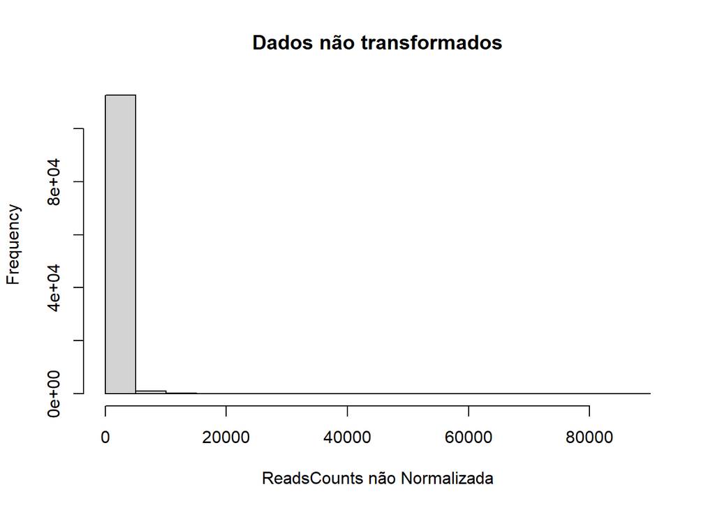

```r
# O Histograma abaixo mostra a distribuição das counts não normalizados.
hist(countData, xlab = 'ReadsCounts não Normalizada', main= 'Dados não transformados')
```

## rlogTransformation

Esta função transforma os dados de contagem para a escala log2, de uma forma que minimiza as diferenças entre  
as amostras com contagens pequenas e as normaliza em relação ao tamanho da biblioteca.

Quando blind = FALSO, o projeto experimental é usado apenas pelo VST e rlog tranformation no cálculo da estimativa de dispersão gênica, a fim de ajustar a linha de tendência através das dispersões sobre a média.

sendo assim, apenas a linha de tendência é usada pelas transformações, e não as estimativas de dispersão gênicas. Portanto, para visualização, agrupamento ou aplicações de aprendizado de máquina, se tende a recomendar blind = FALSE.

```r
# "Regularized log transformation" para os plots PCAs, clustering e heatmaps,
rld <- rlog(ddsDE)

# As informações em um objeto SummarizedExperiment(ex: rld) podem ser acessadas com funçõe assay() que
# retorma uma matriz com os dados reais, ou seja, as contagens de reads.
assay_rld <-assay(rld)

head(assay_rld)
```

```
##                    SRR10493810 SRR10493811 SRR10493818 SRR10493819
## ENSCGRG00015000179    9.702732    9.671434    9.419651    9.359353
## ENSCGRG00015000181    1.963222    1.999106    1.915649    1.954545
## ENSCGRG00015000198    8.974136    8.934056    9.505683    9.512930
## ENSCGRG00015000295   10.719387   11.233819   10.817822   10.930125
## ENSCGRG00015000322    1.849822    1.786758    1.720982    1.721140
## ENSCGRG00015000363    4.834635    4.848849    4.507112    4.547218
```